# Wine Features

Author

Calvin Deutschbein

Published

February 3, 2025

**Abstract:**

This is a technical blog post of **both** an HTML file *and* .qmd file hosted on GitHub pages.

# Setup

**Step Up Code:**

```r
sh <- suppressPackageStartupMessages
sh(library(tidyverse))
sh(library(caret))
sh(library(fastDummies))
wine <- readRDS(gzcon(url("https://github.com/cd-public/D505/raw/master/dat/wine.rds")))
```

**Explanataion:**

> We will proceed as follows:  
> - Suppress `library` load warnings, as we addressed them prior to publication.  
> - Use Tidy data sets via the `tidyverse` package  
> - Perform classification and regression via the `caret` package  
> - Engineer features via the `fastDummies` package  
> - Load in the `wine.rds` dataframe, hosted publicly on [GitHub](https://github.com/cd-public/D505/raw/master/dat/wine.rds).

# Feature Engineering

We begin by engineering an number of features.

```r
wino <- wine %>%
  mutate(lprice=log(price), description = tolower(description)) %>%
  select(lprice, description)
```

```r
notes <- c("smoke", "spice", "pepper", "grass", "tannic", "crisp", "acidic", "bright", "smooth")
for (note in notes) {
  wino <- wino %>%
    mutate(!!sym(note) := str_detect(description, note))
}
head(wino)
```

```
# A tibble: 6 × 11
  lprice description  smoke spice pepper grass tannic crisp acidic bright smooth
   <dbl> <chr>        <lgl> <lgl> <lgl>  <lgl> <lgl>  <lgl> <lgl>  <lgl>  <lgl>
1   2.71 this is rip… FALSE FALSE FALSE  FALSE FALSE  FALSE FALSE  FALSE  TRUE
2   2.64 tart and sn… FALSE FALSE FALSE  FALSE FALSE  TRUE  FALSE  FALSE  FALSE
3   2.56 pineapple r… FALSE FALSE FALSE  FALSE FALSE  FALSE FALSE  FALSE  FALSE
4   4.17 much like t… FALSE FALSE FALSE  FALSE TRUE   FALSE FALSE  FALSE  FALSE
5   2.71 blackberry … FALSE FALSE FALSE  FALSE FALSE  FALSE FALSE  FALSE  FALSE
6   2.77 here's a br… FALSE FALSE TRUE   FALSE FALSE  FALSE FALSE  TRUE   FALSE
```

2. Remove all rows with a missing value.
3. Ensure only log(price) and engineering features are the only columns that remain in the `wino` dataframe.

```r
wino <- wino %>% select(-description) %>% drop_na(.)
```

# Caret

We now use a train/test split to evaluate the features.

1. Use the Caret library to partition the wino dataframe into an 80/20 split.

```r
set.seed(505)  # For reproducibility
trainIndex <- createDataPartition(wino$lprice, p = 0.8, list = FALSE)
trainData <- wino[trainIndex, ]
testData <- wino[-trainIndex, ]
```

2. Run a linear regression with bootstrap resampling.

```r
options(warn=-1)
model <- train(lprice ~ ., data = trainData, method = "lm", trControl = trainControl(method = "boot", number = 5))
options(warn=0)
```

3. Report RMSE on the test partition of the data.

```r
sqrt(mean((predict(model, newdata = testData) - testData$lprice)^2))
```

```
[1] 0.6475555
```

# Variable selection

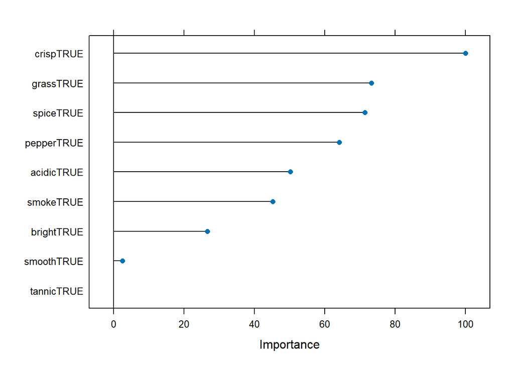

```r
plot(varImp(model))
```